# Human Activity Recognition - Problem statement 12 - Group 186

Group No Name Student Email id % Contribution \ 186 Sivarajan N 2021FC04989@wilp.bits-pilani.ac.in Equal (100%) \ 186 Sindhu C 2021FC04993@wilp.bits-pilani.ac.in Equal (100%) \ 186 Manibalan S 2021fc04442@wilp.bits-pilani.ac.in None (0%)

The purpose of this notebook is to get you started to solve this problem.

The main requirements are listed below which follows a standard Data Science Project:

- Presteps
1. Download Dataset from Google Drive - https://drive.google.com/file/d/1ukwa4aQM_0dGAPzIpSzApE2Gj5qT0ZKn/view?usp=sharing
2. Import the required libraries
- I - Data Visualization & Exploration
  1. Print 2 rows for sanity check to identify all the features present in the dataset and if the target matches with them.
  2. Comment on class imbalance with appropriate visualization method.
  3. Provide appropriate visualizations to get an insight about the dataset.
  4. Do the correlational analysis on the dataset. Provide a visualization for the same. Justify the answer by answering this - Will this correlational analysis have effect on feature selection that we will perform in the next step?
- II - Data Preprocessing, Feature Engineering & Cleaning
  1. Do the appropriate pre-processing of the data like identifying NULL or Missing Values if any, handling of outliers if present in the dataset, skewed data etc. Mention the pre-processing steps performed in the markdown cell.
  2. Apply appropriate feature engineering techniques for them. Apply the feature transformation techniques like Standardization, Normalization, etc. Apply the appropriate transformations depending upon the structure and the complexity of the dataset. Provide proper justification.
- III - Model Building
  1. Split the dataset into training and test sets. Justify the choice of split. Experiment with different split to get the final split. Justify the method chosen.
  2. Build Model Development using Logistic Regression with penalty= l1 and l2, C= [1,0.5,0.1,0.01,0.003] . Identify the best parameter and justify your answer.
- IV - Validation, Performance Evaluation, Testing
  1. Do the prediction for the test data and display the results for the inference. Calculate all the evaluation metrics and choose best for the model chosen.
  2. Comment on under fitting/overfitting/just right model. Justify the chosen model

## Presteps

```
- Data is downloaded and saved in the same folder as this python notebook.
- Let's start by importing common data science packages/libraries
```

```python
import numpy as np # linear algebra
import pandas as pd # data processing, CSV file I/O (e.g. pd.read_csv)
import matplotlib.pyplot as plt # data visualization
import seaborn as sns # data visualization advanced
```

## I - Data Visualization & Exploration

```
1. Lets Print the first 2 rows for sanity check
2. Comment on class imbalance with appropriate visualization method.
3. Provide appropriate visualizations to get an insight about the dataset.
4. Do the correlational analysis on the dataset. Provide a visualization for the same. Justify the answer by answering this - Will this correlational analysis have effect on feature selection that we will perform in the next step?
```

# Loading the Data

```python
df_dataset = pd.read_csv('Human_activity_Dataset.csv')
```

```python
df_dataset.head(2)
```

|  | tBodyAcc-mean()-X | tBodyAcc-mean()-Y | tBodyAcc-mean()-Z | tBodyAcc-std()-X | tBodyAcc-std()-Y | tBodyAcc-std()-Z | tBodyAcc-mad()-X | tBodyAcc-mad()-Y | tBodyAcc-mad()-Z | tBodyAcc-max()-X | ... | fBodyBodyGyroJerkMag-kurtosis() | angle(tBodyAccMean,gravity) | angle(tBodyAccJerkMean),gravityMean) | angle(tBodyGyroMean,gravityMean) | angle(tBodyGyroJerkMean,gravityMean) | angle(X,gravityMean) | angle(Y,gravityMean) | angle(Z,gravityMean) | subject/Participant | Activity |
| --- | --- | --- | --- | --- | --- | --- | --- | --- | --- | --- | --- | --- | --- | --- | --- | --- | --- | --- | --- | --- | --- |
| 0 | 0.288585 | -0.020294 | -0.132905 | -0.995279 | -0.983111 | -0.913526 | -0.995112 | -0.983185 | -0.923527 | -0.934724 | ... | -0.710304 | -0.112754 | 0.030400 | -0.464761 | -0.018446 | -0.841247 | 0.179941 | -0.058627 | 1 | STANDING |
| 1 | 0.278419 | -0.016411 | -0.123520 | -0.998245 | -0.975300 | -0.960322 | -0.998807 | -0.974914 | -0.957686 | -0.943068 | ... | -0.861499 | 0.053477 | -0.007435 | -0.732626 | 0.703511 | -0.844788 | 0.180289 | -0.054317 | 1 | STANDING |

2 rows × 563 columns

- 563 columns including subject/participant and Activity is present in the data rows.
- We are able to identify that all the features are present in the dataset and the target matches with them.

#### 1. How many features are there? What are their datatypes?

```python
df_dataset.shape
```

```
(10299, 563)
```

```python
df_dataset.dtypes.value_counts()
```

```
float64    561
int64        1
object       1
dtype: int64
```

```python
df_dataset.select_dtypes('int64').head(3)
```

|  | subject/Participant |
| --- | --- |
| 0 | 1 |
| 1 | 1 |
| 2 | 1 |

```python
df_dataset.select_dtypes('object').head(3)
```

|  | Activity |
| --- | --- |
| 0 | STANDING |
| 1 | STANDING |
| 2 | STANDING |

#### 2. Summarize the features

```python
import re
```

Looking at some of the names of the features, it seems that these are derived features from raw sensor data. \ The features starting with small 't' are time-domain features.\ The features starting with small 'f' are frequency-domain features.

```python
columns = df_dataset.columns.to_numpy()
```

```python
time_feats = []
time_func = set()
freq_feats = []
freq_func = set()
other_feats = []

n_time = 0
n_freq = 0
n_other = 0

regex_func = re.compile('-([a-z]+)')
regex_axis = re.compile('-([A-Z])')

for i in range(563):
    if np.char.startswith(columns[i],'t'):
        time_feats.append(columns[i])
        time_func.add(regex_func.findall(columns[i])[0])
        n_time += 1
    elif np.char.startswith(columns[i],'f'):
        freq_feats.append(columns[i])
        freq_func.add(regex_func.findall(columns[i])[0])
        n_freq += 1
    else:
        other_feats.append(columns[i])
        n_other += 1
```

```python
print('Time features:',sorted(time_func))
print('Frequency features:',sorted(freq_func))
```

```
Time features: ['ar', 'correlation', 'energy', 'entropy', 'iqr', 'mad', 'max', 'mean', 'min', 'sma', 'std']
Frequency features: ['bands', 'energy', 'entropy', 'iqr', 'kurtosis', 'mad', 'max', 'mean', 'min', 'skewness', 'sma', 'std']
```

```python
print('Other features:',sorted(other_feats))
```

```
Other features: ['Activity', 'angle(X,gravityMean)', 'angle(Y,gravityMean)', 'angle(Z,gravityMean)', 'angle(tBodyAccJerkMean),gravityMean)', 'angle(tBodyAccMean,gravity)', 'angle(tBodyGyroJerkMean,gravityMean)', 'angle(tBodyGyroMean,gravityMean)', 'subject/Participant']
```

```python
n_time, n_freq, n_other, n_time + n_freq + n_other
```

```
(265, 289, 9, 563)
```

#### 3. Is the target balanced? Let's check with appropriate visualization method.

```python
df_dataset['Activity'].value_counts()
```

```
LAYING                1944
STANDING              1906
SITTING               1777
WALKING               1722
WALKING_UPSTAIRS      1544
WALKING_DOWNSTAIRS    1406
Name: Activity, dtype: int64
```

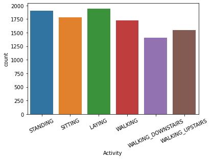

```python
chart = sns.countplot(df_dataset['Activity'])
t = chart.set_xticklabels(chart.get_xticklabels(),rotation=25)
```

#### Class Imbalance:

```
- Data Seems more or less balanced.
```

#### 4. Visualization for correlational analysis:

- The simplest way to visualize correlation is to create a scatter plot of the two variables.

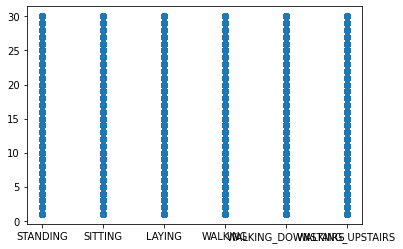

```python
plt.scatter(df_dataset['Activity'],df_dataset['subject/Participant'])
plt.show()
```

### Justification:

[output not shown]

## II - Data Preprocessing, Feature Engineering & Cleaning

#### 1. Data Preprocessing steps - null check, missing value check, handling outliers, checking skewed data.

```python
df_dataset.isnull().sum()
```

```
tBodyAcc-mean()-X       0
tBodyAcc-mean()-Y       0
tBodyAcc-mean()-Z       0
tBodyAcc-std()-X        0
tBodyAcc-std()-Y        0
                       ..
angle(X,gravityMean)    0
angle(Y,gravityMean)    0
angle(Z,gravityMean)    0
subject/Participant     0
Activity                0
Length: 563, dtype: int64
```

There are no null values, so there are no standard missing values that pandas can detect.

### Detecting outliers using the Z-scores and Boxplot methods

```python
outliers = []
def detect_outliers_zscore(data):
    thres = 3
    mean = np.mean(data)
    std = np.std(data)
    # print(mean, std)
    for i in data:
        z_score = (i-mean)/std
        if (np.abs(z_score) > thres):
            outliers.append(i)
    return outliers# Driver code
data_outliers = detect_outliers_zscore(df_dataset['subject/Participant'])
print("Outliers from Z-scores method: ", data_outliers)
```

```
Outliers from Z-scores method:  []
```

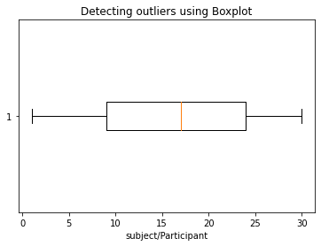

```python
plt.boxplot(df_dataset['subject/Participant'], vert=False)
plt.title("Detecting outliers using Boxplot")
plt.xlabel('subject/Participant')
```

There are no outliers in this dataset for 'subject/Participant' data.

The following Data Pre-processing steps were done for this exercise:

- identifying NULL or Missing Values if any
- handling of outliers if present in the dataset

#### 2. Feature Engineering - Which features are important?

```python
act_map = {'STANDING':0, 'SITTING':1, 'LAYING':2, 'WALKING':3, 'WALKING_DOWNSTAIRS':4, 'WALKING_UPSTAIRS':5}
df_dataset['activity_code'] = df_dataset['Activity'].map(act_map)
```

```python
df_dataset['activity_code'].value_counts()
```

```
2    1944
0    1906
1    1777
3    1722
5    1544
4    1406
Name: activity_code, dtype: int64
```

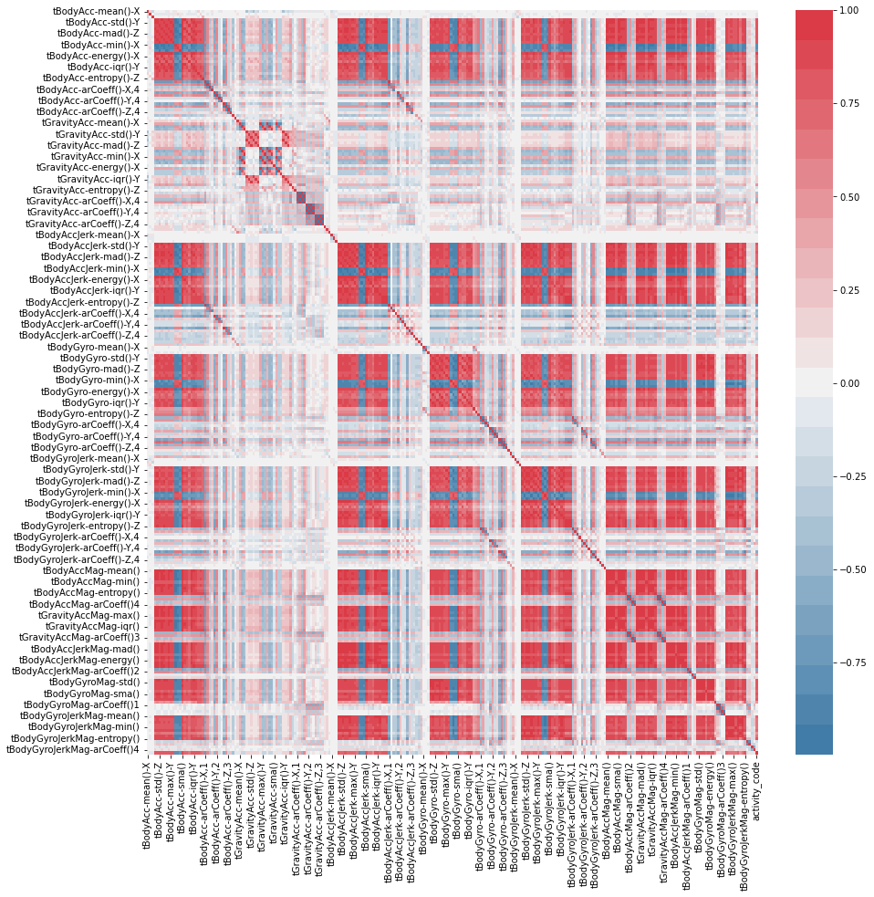

```python
fig, ax = plt.subplots(1,1, figsize=(15,15))
sns.heatmap(df_dataset[time_feats+['activity_code']].corr(),
            cmap=sns.diverging_palette(240, 10, n=25),
            cbar=True,ax=ax)
```

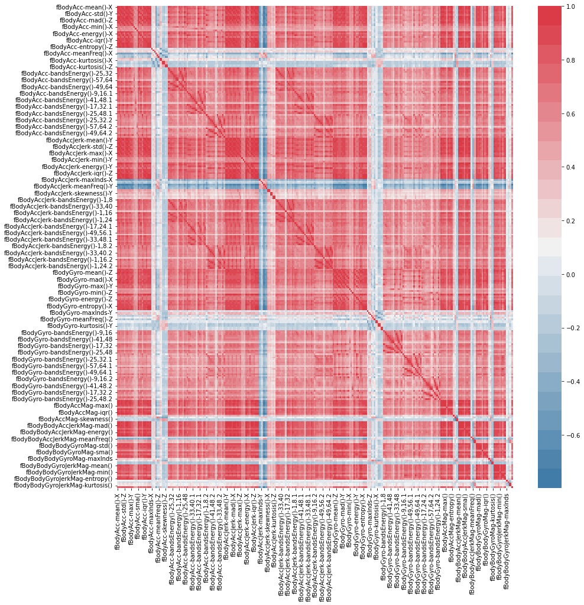

```python
fig, ax = plt.subplots(1,1, figsize=(15,15))
sns.heatmap(df_dataset[freq_feats+['activity_code']].corr(),
            cmap=sns.diverging_palette(240, 10, n=25),
            cbar=True,ax=ax)
```

# III - Model Building

### Split the dataset into training and test sets:

```
- Justify the choice of split. Experiment with different split to get the final split. Justify the method chosen.
```

```python
from sklearn.model_selection import train_test_split, KFold, GridSearchCV
```

Let's come up with a quick base model before further exploring the data. \ Firstly, let's remove subject, Activity from the data. And then split the data to train and test data sets.

```python
df_dataset.drop(columns=['subject/Participant','Activity'], inplace=True)
```

```python
y = df_dataset.pop('activity_code')
X = df_dataset
```

```python
X.shape, y.shape
```

```
((10299, 561), (10299,))
```

### Justification - Lets' use 80:20 split

- Since the number of values is 10299, 80:20 is better than 70:30.
- With datasets containing considerably high observations like ours (> 10,000), 80:20 is a good starting point. Overall, we need to make sure that the test set represents most of the variance in the dataset. We can ensure this by trying different amounts of test data.

```python
X_train, X_test, y_train, y_test = train_test_split(X, y, test_size=0.2, stratify=y)
```

```python
X_train.shape, y_train.shape
```

```
((8239, 561), (8239,))
```

```python
X_test.shape, y_test.shape
```

```
((2060, 561), (2060,))
```

```
- Build Model Development using Logistic Regression with penalty= l1 and l2, C= [1,0.5,0.1,0.01,0.003] . Identify the best parameter and justify your answer.

- Penalized logistic regression imposes a penalty to the logistic model for having too many variables. This results in shrinking the coefficients of the less contributive variables toward zero. This is also known as regularization.

- In Machine Learning, L1 tends to shrink coefficients to zero whereas L2 tends to shrink coefficients evenly. L1 is therefore useful for feature selection, as we can drop any variables associated with coefficients that go to zero. L2, on the other hand, is useful when you have collinear/codependent features. For our case, we use L1 since we need drop variabls.
```

```python
from sklearn.preprocessing import StandardScaler
from sklearn.linear_model import LogisticRegression
from sklearn.svm import SVC
from sklearn import preprocessing

from sklearn.metrics import classification_report
```

Let's do feature standardization before training the models

```python
std_scaler = StandardScaler()
le = preprocessing.LabelEncoder()
X_train = X_train.apply(le.fit_transform) # this is needed to avoid string transformation
X_test = X_test.apply(le.fit_transform) # this is needed to avoid string transformation

X_prep_train = std_scaler.fit_transform(X_train)
X_prep_test = std_scaler.transform(X_test)
```

### Justification - Feature transformation techniques using Standardization

```
- Standardization is a scaling technique where the values are centered around the mean with a unit standard deviation. This means that the mean of the attribute becomes zero and the resultant distribution has a unit standard deviation.
- Normalization is a scaling technique in which values are shifted and rescaled so that they end up ranging between 0 and 1.
- The appropriate transformation depending upon the structure and the complexity of our dataset is Standardization. Unlike normalization, standardization does not have a bounding range.
```

## Training the models

```python
# Perform GridSearchCV to tune best-fit LR model
param = {'C': [1,0.5,0.1,0.01,0.003]}

LR_clf = LogisticRegression(penalty='l1', solver='liblinear') # liblinear supports logistic regression (LR) L1-regularized classifiers
gs_model = GridSearchCV(estimator=LR_clf, param_grid=param)
gs_model.fit(X_prep_train, y_train)

y_pred = gs_model.predict(X_prep_train)
print(classification_report(y_train, y_pred))
```

```
              precision    recall  f1-score   support

           0       0.99      0.98      0.98      1525
           1       0.98      0.99      0.98      1421
           2       1.00      1.00      1.00      1555
           3       1.00      1.00      1.00      1378
           4       1.00      1.00      1.00      1125
           5       1.00      1.00      1.00      1235

    accuracy                           0.99      8239
   macro avg       0.99      0.99      0.99      8239
weighted avg       0.99      0.99      0.99      8239
```

**WOW** - that was a good Classification.

### Justification:

Let's check for validation data

```python
from sklearn.model_selection import cross_val_score, KFold
```

```python
kfold = KFold(n_splits=5)
```

```python
scores = cross_val_score(LR_clf, X_prep_train, y_train, scoring='accuracy', cv=kfold)
print('Scores:',scores)
print('Mean:',np.mean(scores))
print('Std:',np.std(scores))
```

```
Scores: [0.98786408 0.98118932 0.9836165  0.98604369 0.98239223]
Mean: 0.9842211641053755
Std: 0.0024287903464436478
```

**Amazing** \ How about on the test set?

```python
gs_model.fit(X_prep_test, y_test)
y_pred = gs_model.predict(X_prep_test)

print(classification_report(y_test, y_pred))
```

```
              precision    recall  f1-score   support

           0       0.98      0.97      0.97       381
           1       0.96      0.97      0.96       356
           2       0.99      1.00      0.99       389
           3       1.00      1.00      1.00       344
           4       1.00      1.00      1.00       281
           5       1.00      1.00      1.00       309

    accuracy                           0.99      2060
   macro avg       0.99      0.99      0.99      2060
weighted avg       0.99      0.99      0.99      2060
```

# Testing

```python
df_dataset = df_dataset.reindex(labels=df_dataset.columns,axis=1)
X_final_test = df_dataset
```

```python
X_final_prep_test = std_scaler.transform(X_final_test)
```

```python
y_final_pred = gs_model.predict(X_final_prep_test)
```

```python
y_final_pred
```

```
array([1, 1, 1, ..., 1, 1, 1], dtype=int64)
```

```python
rev_act_map = {0:'STANDING', 1:'SITTING', 2:'LAYING', 3:'WALKING', 4:'WALKING_DOWNSTAIRS', 5:'WALKING_UPSTAIRS'}
y_final = [rev_act_map[code] for code in y_final_pred]
```

```python
submission = pd.DataFrame({
        "Id": range(1,len(y_final)+1),
        "Activity": y_final
    })

submission.to_csv('lr_sub.csv',index=False)
```

```python
submission.head()
```

|  | Id | Activity |
| --- | --- | --- |
| 0 | 1 | SITTING |
| 1 | 2 | SITTING |
| 2 | 3 | SITTING |
| 3 | 4 | SITTING |
| 4 | 5 | SITTING |

### Justifcation - under fitting/overfitting/just right model

Ideally, you want to select a model at the sweet spot between underfitting and overfitting.

There are three main methods to avoid overfitting: \ 1- Keep the model simpler: reduce variance by taking into account fewer variables and parameters, thereby removing some of the noise in the training data. \ 2- Use cross-validation techniques such as k-folds cross-validation. \ 3- Use regularization techniques such as Linear Regression that penalize certain model parameters if they’re likely to cause overfitting.